# Data Visualization - Mini-Project 1

```r
NA
NA
```

| teamname | home_wins | away_wins |
| --- | --- | --- |
| Brazil | 59 | 10 |
| Argentina | 41 | 14 |
| Italy | 38 | 12 |
| Germany FR | 29 | 11 |
| England | 22 | 14 |
| France | 19 | 14 |
| Mexico | 8 | 24 |
| Uruguay | 16 | 15 |
| Hungary | 15 | 13 |
| Germany | 24 | 3 |

[output cut: 10 more lines]

| teamname | location_win | score |
| --- | --- | --- |
| Brazil | home_wins | 59 |
| Argentina | home_wins | 41 |
| Italy | home_wins | 38 |
| Germany FR | home_wins | 29 |
| England | home_wins | 22 |
| France | home_wins | 19 |
| Mexico | home_wins | 8 |
| Uruguay | home_wins | 16 |
| Hungary | home_wins | 15 |
| Germany | home_wins | 24 |

[output cut: 30 more lines]

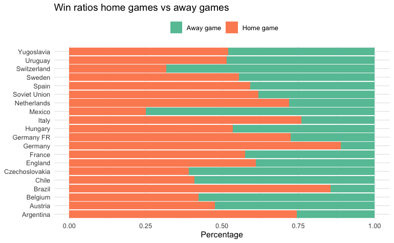

```r
#proportion home wins vs away wins, Does home offers a good advantage for some teams over others


joined_df %>%
  select(teamname, home_wins, away_wins, total_wins) %>%
  arrange(desc(total_wins)) %>%
  head(20) %>%
  select(-total_wins) %>%
  print() %>%
  gather(location_win, score, -teamname) %>%
  print() %>%
  ggplot(aes(x=teamname, y=score, fill=location_win)) +
  geom_bar(position = "fill", stat = "identity") +
  coord_flip() +
  theme_minimal() +
  scale_fill_brewer(name = "", labels = c("Away game", "Home game"), palette="Set2") +
  theme(axis.title.y=element_blank(), legend.position = "top")+
  labs(title="Win ratios home games vs away games", y="Percentage")
```

```r
NA
NA
```

```r
#do the countries win with big score gap, make box plot
#winning score gap and losing score gap

home_team_wins <- my_data %>%
  mutate(score_gap=`Home Team Goals`- `Away Team Goals`) %>%
  filter(score_gap > 0) %>%
  select(`Home Team Name`, score_gap) %>%
  rename(teamname= `Home Team Name`)




away_team_wins <- my_data %>%
  mutate(score_gap=`Away Team Goals`- `Home Team Goals`) %>%
  filter(score_gap > 0) %>%
  select(`Away Team Name`, score_gap) %>%
  rename(teamname= `Away Team Name`)


total_gap <- rbind(away_team_wins, home_team_wins)

total_gap
```

| teamname | score_gap |
| --- | --- |
| Germany FR | 2 |
| Scotland | 2 |
| Netherlands | 2 |
| Germany FR | 3 |
| Poland | 7 |
| Brazil | 3 |
| Netherlands | 3 |
| Germany FR | 2 |
| Poland | 1 |
| Brazil | 1 |

[output cut: 652 more lines]

```r
#remove countries with only 1 game

countries_count <- total_gap %>%
  group_by(teamname) %>%
  count(sort=T) %>%
  filter(n>5) %>%
  print()
```

| teamname | n |
| --- | --- |
| Brazil | 71 |
| Italy | 45 |
| Argentina | 44 |
| Germany FR | 36 |
| Germany | 34 |
| France | 29 |
| Netherlands | 29 |
| Spain | 29 |
| England | 26 |
| Uruguay | 20 |

[output cut: 18 more lines]

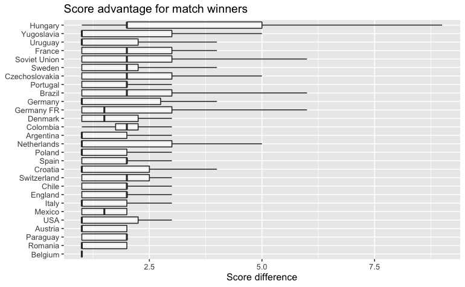

```r
total_gap %>%
  right_join(countries_count, by="teamname") %>%
  ggplot() +
  geom_boxplot( aes(x=fct_reorder(as.factor(teamname), score_gap , mean), y=score_gap), outlier.shape = NA, alpha=0.5) +
  coord_flip() +
  theme(axis.title.y=element_blank(), legend.position = "top")+
  labs(title="Score advantage for match winners", y="Score difference")
```

```r
NA
NA
NA
```

I used a horizontal bar graph to perform analysis on when the teams score the most points in a match. The percentage is calculated based on the half time score over the total score of the time to judge whether the team tends to score more goals before or after the half time mark. From the graph, countries like USA and Paraguay have a high average for the percentage of points scored before the half time mark, while countries like Colombia have more endurance and tends to score more points after the half time mark.

```r
#how does score at half time affects the result
#which teams tends to have better first half performance over second half
#need to remove those that have 0 scores total games
#based on winning games


#winning team's performance on the first half of the game

game_scores <- my_data %>%
  mutate(home_score_ratio= (`Half-time Home Goals` / `Home Team Goals`)*100, away_score_ratio =(`Half-time Away Goals` / `Away Team Goals`)*100) %>%
  replace(is.na(.), 0) %>%
  select(`Home Team Name`, `Away Team Name`, home_score_ratio, away_score_ratio, `Home Team Goals`, `Away Team Goals`) %>%
  print()
```

| Home Team Name | Away Team Name | home_score_ratio | away_score_ratio | Home Team Goals | Away Team Goals |
| --- | --- | --- | --- | --- | --- |
| France | Mexico | 75.00000 | 0.00000 | 4 | 1 |
| USA | Belgium | 66.66667 | 0.00000 | 3 | 0 |
| Yugoslavia | Brazil | 100.00000 | 0.00000 | 2 | 1 |
| Romania | Peru | 33.33333 | 0.00000 | 3 | 1 |
| Argentina | France | 0.00000 | 0.00000 | 1 | 0 |
| Chile | Mexico | 33.33333 | 0.00000 | 3 | 0 |
| Yugoslavia | Bolivia | 0.00000 | 0.00000 | 4 | 0 |
| USA | Paraguay | 66.66667 | 0.00000 | 3 | 0 |
| Uruguay | Peru | 0.00000 | 0.00000 | 1 | 0 |
| Chile | France | 0.00000 | 0.00000 | 1 | 0 |

[output cut: 990 more lines]

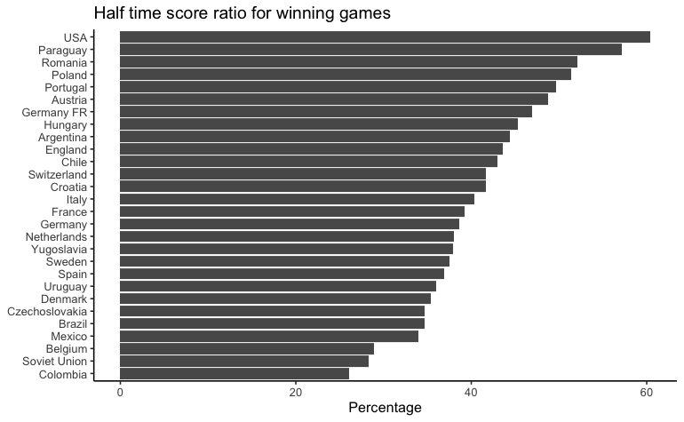

```r
home_game_data <- game_scores %>%
  filter(`Home Team Goals` > `Away Team Goals`) %>%
  select(`Home Team Name`, home_score_ratio) %>%
  rename(teamname=`Home Team Name`, first_half_score_ratio = home_score_ratio)

away_game_data <- game_scores %>%
   filter(`Home Team Goals` < `Away Team Goals`) %>%
   select(`Away Team Name`, away_score_ratio) %>%
   rename(teamname=`Away Team Name`, first_half_score_ratio = away_score_ratio)


total_data <- rbind(home_game_data, away_game_data) %>%
  right_join(countries_count, by="teamname")





total_data %>%
  group_by(teamname) %>%
  summarise(avg_half_time_ratio=mean(first_half_score_ratio)) %>%
  ggplot(aes(x=fct_reorder(teamname, avg_half_time_ratio), y=avg_half_time_ratio, fill=)) +
  geom_bar(stat = "identity") +
  coord_flip() +
  theme_classic() +
  theme(axis.title.y=element_blank(), legend.position = "top")+
  labs(title="Half time score ratio for winning games", y="Percentage")
```

```r
NA
NA
NA
NA
```